# Multivariate Bayesian variable selection regression

## Summarizing EB based mvSuSiE

I have used several other notebooks for simulating and learning priors via EB approach. This notebook puts togather what we have.

- Generate prior mixture for simulation.
- Generate eQTL summary statistics and learn mixture prior.

## EB prior learned for artificial mixture

Here are the weights assigned for this simulation, with 50 conditions.

1. singleton total 35%
   - singleton_1 has 10% (to be picked up later by ED methods)
   - singleton_2 to singleton_26 has 25% (1% each )
2. shared total 25%
3. paired 20% (hopefully picked up by ED methods)
4. blocked 20% (hopefully picked up by ED methods)

Here is the EB result (using extreme deconvolution), for FLASH, X'X and PCA:

> ../dsc/mnm_prototype/mnm_sumstats/artificial_mixture_eb.png (25.3 KiB):

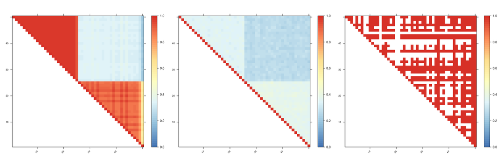

```python
%preview ../dsc/mnm_prototype/mnm_sumstats/artificial_mixture_eb.png
```

For GTEx mixture based simulation, I first learned from GTEx V8 data using extreme deconvolution the actual weight and mixture matrices, then use that for simulation. With simulated data I learn again the mixture and their weights using extreme deconvolution. Here is the result for FLASH, PCA and X'X:

> ../dsc/mnm_prototype/mnm_sumstats/gtex_mixture_eb.png (26.7 KiB):

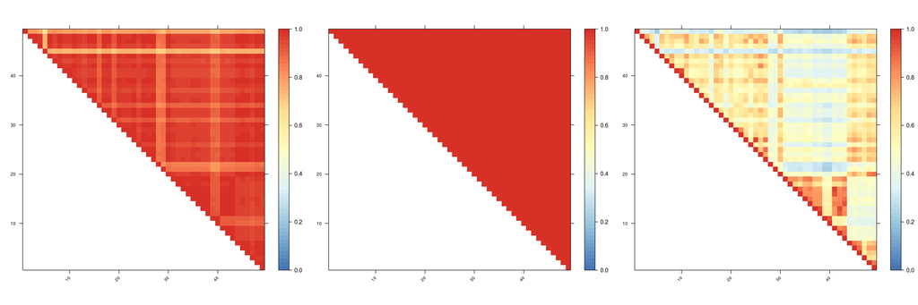

```python
%preview ../dsc/mnm_prototype/mnm_sumstats/gtex_mixture_eb.png
```

Please checkout this page for more details.

## Results from 50 condition simulations

### Global PIP calibration for mvSuSiE

```python
%cd ../dsc/mnm_prototype/mnm_20200510
```

```
/home/gw/GIT/github/mvarbvs/dsc/mnm_prototype/mnm_20200510
```

artificial mixture,

> PIP_comparison_0510.artificial_mixture.global.pip_evaluation.png (65.7 KiB):

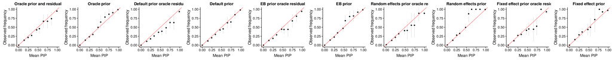

```python
%preview PIP_comparison_0510.artificial_mixture.global.pip_evaluation.png
```

GTEx mixture,

> PIP_comparison_0510.gtex_mixture.global.pip_evaluation.png (66.1 KiB):

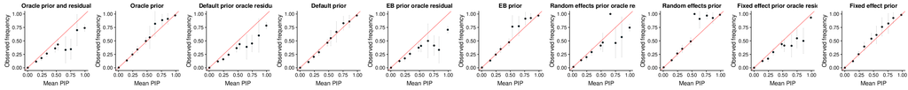

```python
%preview PIP_comparison_0510.gtex_mixture.global.pip_evaluation.png
```

### ROC

artificial mixture,

> PIP_comparison_0510.artificial_mixture.global.roc.pdf (15.2 KiB):

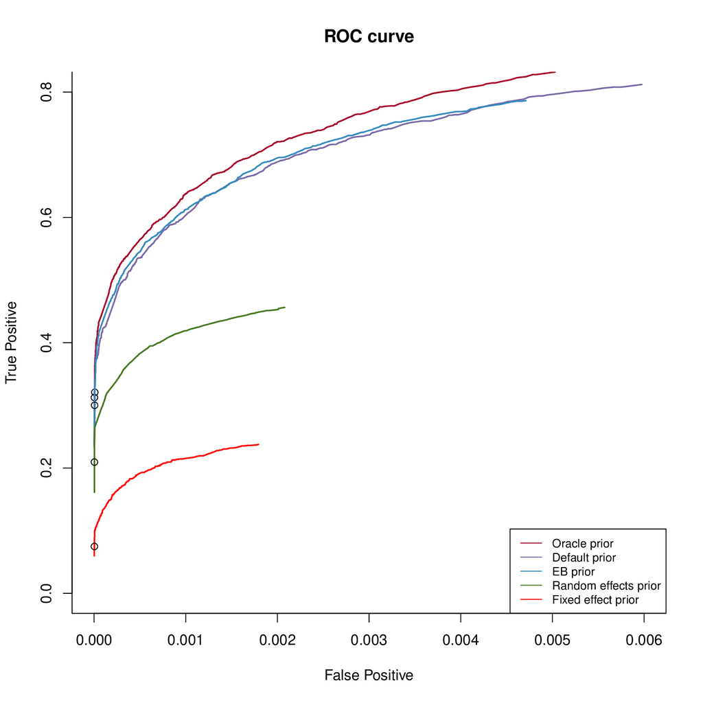

```python
%preview PIP_comparison_0510.artificial_mixture.global.roc.pdf -s png
```

GTEx mixture,

> PIP_comparison_0510.gtex_mixture.global.roc.pdf (15.8 KiB):

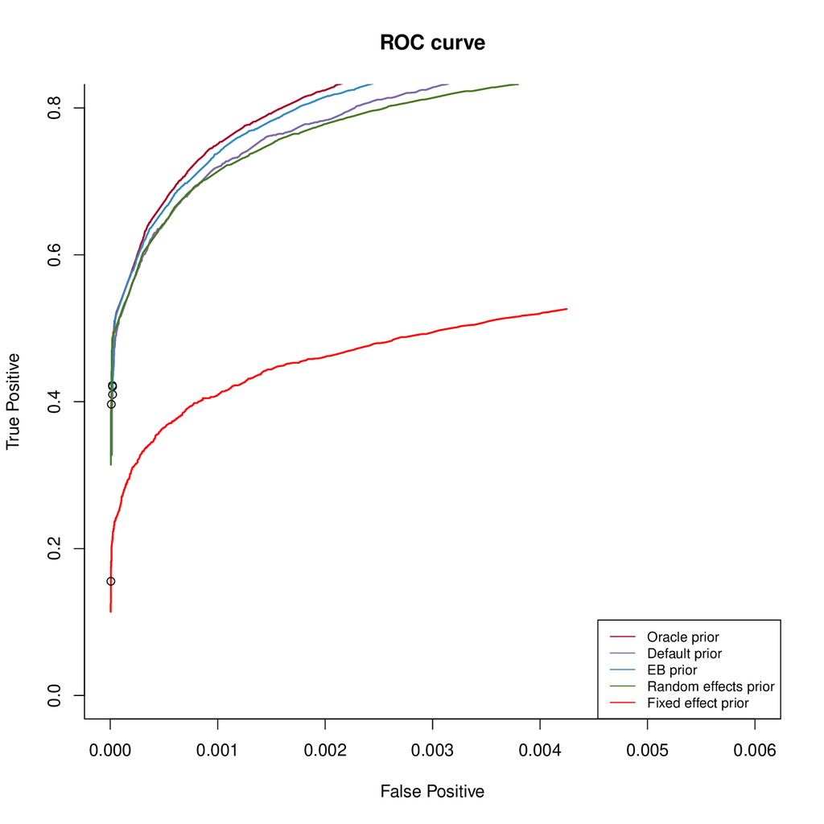

```python
%preview PIP_comparison_0510.gtex_mixture.global.roc.pdf -s png
```

### PR curve

artificial mixture,

> PIP_comparison_0510.artificial_mixture.global.pr.pdf (16.8 KiB):

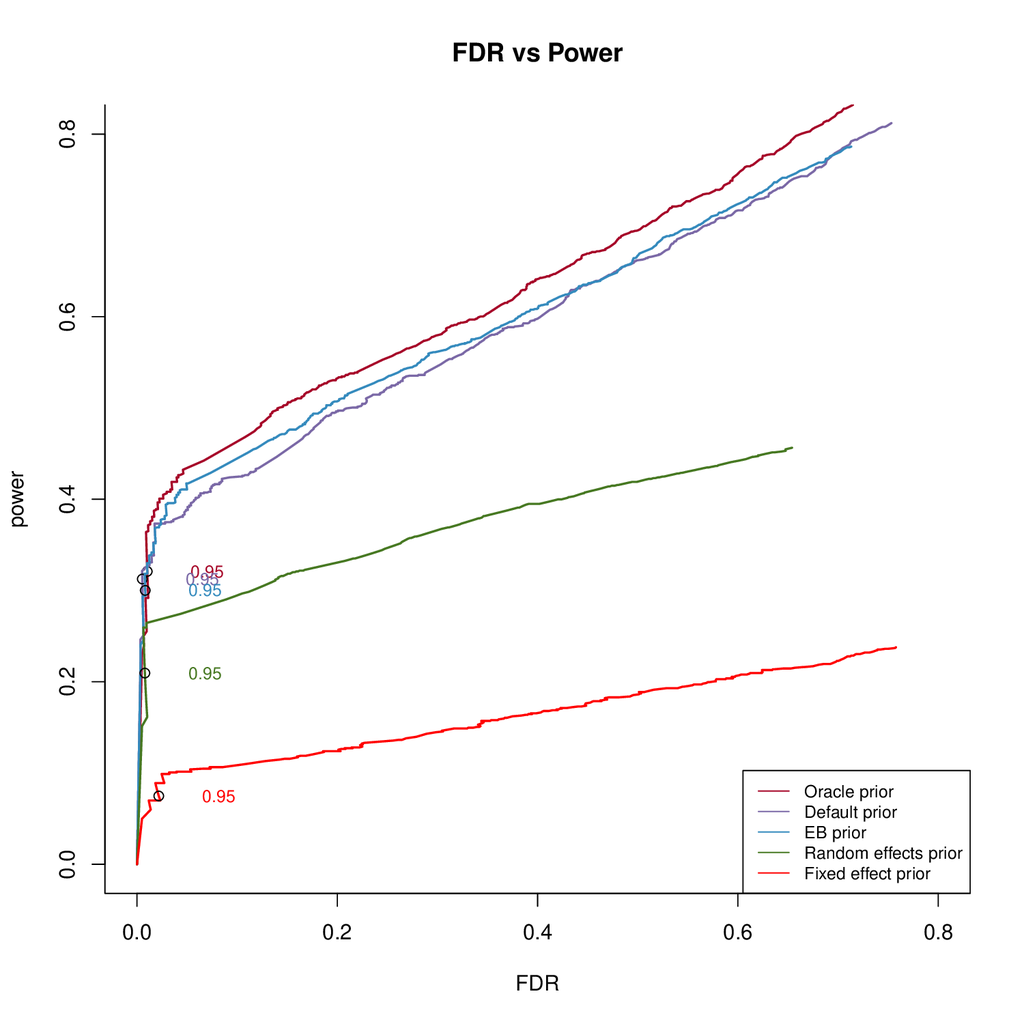

```python
%preview PIP_comparison_0510.artificial_mixture.global.pr.pdf -s png
```

> PIP_comparison_0510.gtex_mixture.global.pr.pdf (17.5 KiB):

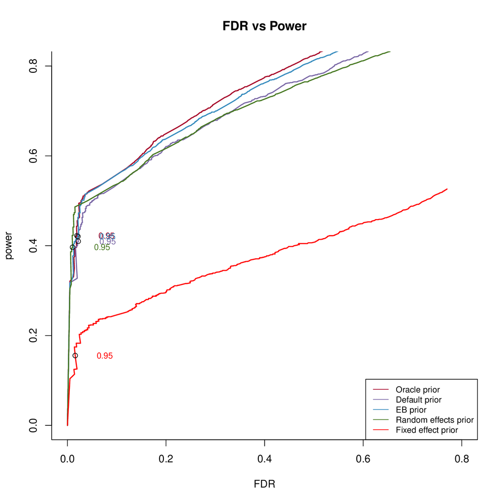

```python
%preview PIP_comparison_0510.gtex_mixture.global.pr.pdf -s png
```

## MT-HESS comparisons

Here I simulated artificial mixture of 6 conditions,

1. singleton total 30%
   - singleton_1, singleton_3, singleton_5 each has 10%
2. shared total 30%
3. paired 20%
4. blocked 20%

I only ran it in 100 replicates (genes), and on 300 variables, because some mt-hess runs takes days to complete.

## Results for MT-HESS comparison

Note here I have to work on `1 - condition specific lfsr` as a proxy to condition specific PIP reported by MT-HESS.

```python
%cd ../mthess_20200526
```

```
/home/gw/GIT/github/mvarbvs/dsc/mnm_prototype/mthess_20200526
```

> PIP_comparison_0526.artificial_mixture_small.pip_evaluation.png (64.8 KiB):

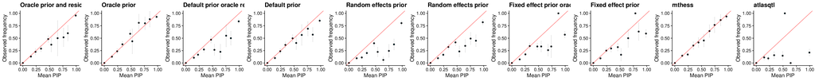

```python
%preview PIP_comparison_0526.artificial_mixture_small.pip_evaluation.png
```

> PIP_comparison_0526.artificial_mixture_small.roc.pdf (14.6 KiB):

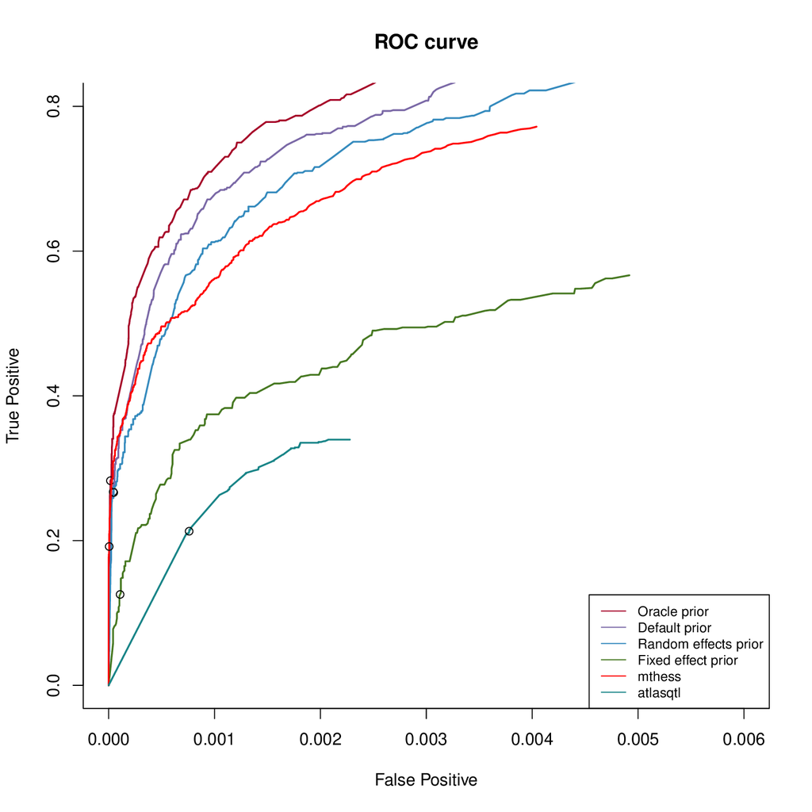

```python
%preview PIP_comparison_0526.artificial_mixture_small.roc.pdf -s png
```

> PIP_comparison_0526.artificial_mixture_small.pr.pdf (15.7 KiB):

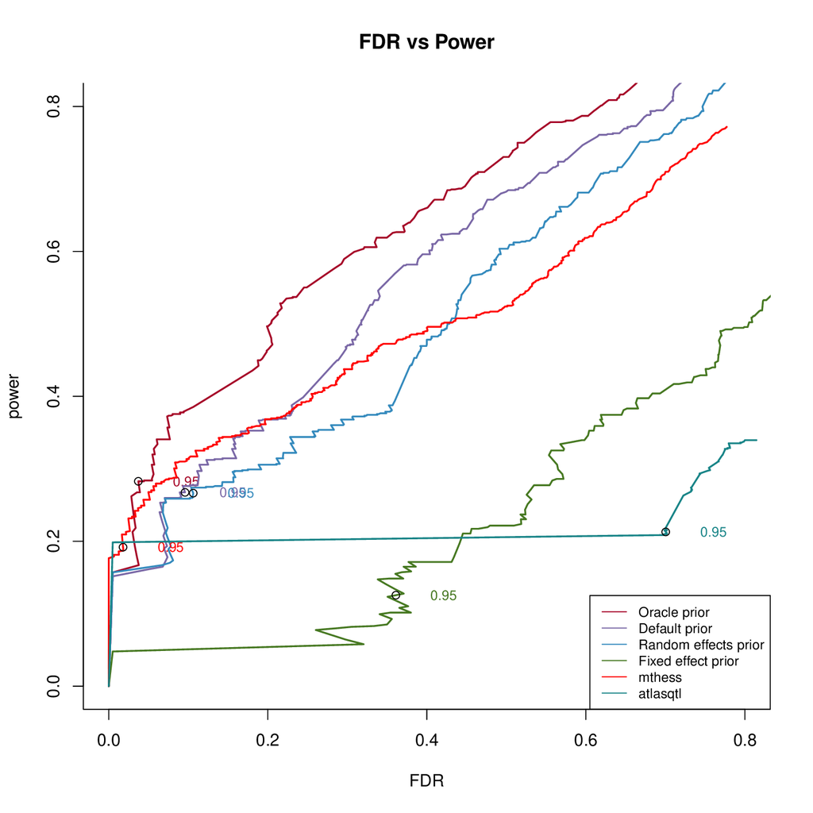

```python
%preview PIP_comparison_0526.artificial_mixture_small.pr.pdf -s png
```

Copyright © 2016-2020 Gao Wang et al at Stephens Lab, University of Chicago